# Final project_Meng Yuan

Meng Yuan

11/22/2019

## Data description:

The data I will be using in this final project are publicly available data from the article: Wang, Y., Klijn, J. G., Zhang, Y., Sieuwerts, A. M., Look, M. P., Yang, F., … Foekens, J. A. (2005). Gene-expression profiles to predict distant metastasis of lymph-node-negative primary breast cancer. The Lancet. https://doi.org/10.1016/s0140-6736(05)17947-1. The data were downloaded from NCBI GEO database (GSE2034).

In this study, the researchers examined the expression levels of about 22,000 genes from 286 lymph node negative breast cancer patient samples. Of all 286 patients, 106 had distant metastasis. From the 22,000 genes they generated a 76-gene profile which enabled them to make predictions whether of not the patient would develop distal metastasis.

## To import the patient ID sheet to R (patient IDs were stored in a txt file):

```r
library(readr)
ID <- read.csv("/Users/myuanmoon/GoogleDrive/PhD_studies/Lectures/Lectures_2019Fall/FAES R/Final project/Data to use/GSE2034-22071_ID.txt")
head(ID)
```

```
##                  ID_REF
## 1 GSM36777 = Sample 277
## 2 GSM36778 = Sample 278
## 3 GSM36779 = Sample 798
## 4 GSM36780 = Sample 846
## 5 GSM36781 = Sample 765
## 6 GSM36782 = Sample 600
```

## As can be seen above, the ID_REF column contains both GSM numbers and sample indexes with a “=” in between. For the convenience of subsequent analysis, I would like to split the ID_REF column into two, one “GSM” column and one “Sample_index” column:

```r
library(tidyverse)
ID_split <- separate(ID, col=ID_REF, into = c("GSM","Sample_index"),sep = "=")
head(ID_split)
```

```
##         GSM Sample_index
## 1 GSM36777    Sample 277
## 2 GSM36778    Sample 278
## 3 GSM36779    Sample 798
## 4 GSM36780    Sample 846
## 5 GSM36781    Sample 765
## 6 GSM36782    Sample 600
```

## Then, I would like to check the data type in ID_split:

The data type for GSM column is:

```r
class(ID_split$GSM)
```

```
## [1] "character"
```

The data type for Sample_index column is:

```r
class(ID_split$Sample_index)
```

```
## [1] "character"
```

## Let’s check if ID_split is a dataframe:

```r
is.data.frame(ID_split)
```

```
## [1] TRUE
```

## Then it’s time to import the gene expression data obtained by the researchers using Affymetrix Human U133a GeneChips (data were stored as xlsx format):

```r
Gene <- readxl::read_excel("/Users/myuanmoon/GoogleDrive/PhD_studies/Lectures/Lectures_2019Fall/FAES R/Final project/Data to use/GSE2034-22071_expression.xlsx")
head(Gene)
```

```
## # A tibble: 6 x 287
##   ID_REF GSM36777 GSM36778 GSM36779 GSM36780 GSM36781 GSM36782 GSM36783 GSM36784
##   <chr>     <dbl>    <dbl>    <dbl>    <dbl>    <dbl>    <dbl>    <dbl>    <dbl>
## 1 1007_…   3848.     6521.   5286.     4044.   4264.    2950.    5499.     3863.
## 2 1053_…    229.      112.    178.      399.    418.     221.     280.      198.
## 3 117_at    213.      190.    270.      312.    327.     225      244.      244.
## 4 121_at   1009.     2083.   1203.     1104.   1043.    1118.    1085.     1423.
## 5 1255_…     31.8     146.     42.5     108.     69.2     47.4     84.3     102
## 6 1294_…    552.      803.    558.      568.    653.     585      553.      711.
## # … with 278 more variables: GSM36785 <dbl>, GSM36786 <dbl>, GSM36787 <dbl>,
## #   GSM36788 <dbl>, GSM36789 <dbl>, GSM36790 <dbl>, GSM36791 <dbl>,
## #   GSM36792 <dbl>, GSM36793 <dbl>, GSM36794 <dbl>, GSM36795 <dbl>,
## #   GSM36796 <dbl>, GSM36797 <dbl>, GSM36798 <dbl>, GSM36799 <dbl>,
## #   GSM36800 <dbl>, GSM36801 <dbl>, GSM36802 <dbl>, GSM36803 <dbl>,
## #   GSM36804 <dbl>, GSM36805 <dbl>, GSM36806 <dbl>, GSM36807 <dbl>,
## #   GSM36808 <dbl>, GSM36809 <dbl>, GSM36810 <dbl>, GSM36811 <dbl>,
## #   GSM36812 <dbl>, GSM36813 <dbl>, GSM36814 <dbl>, GSM36815 <dbl>,
## #   GSM36816 <dbl>, GSM36817 <dbl>, GSM36818 <dbl>, GSM36819 <dbl>,
## #   GSM36820 <dbl>, GSM36821 <dbl>, GSM36822 <dbl>, GSM36823 <dbl>,
## #   GSM36824 <dbl>, GSM36825 <dbl>, GSM36826 <dbl>, GSM36827 <dbl>,
## #   GSM36828 <dbl>, GSM36829 <dbl>, GSM36830 <dbl>, GSM36831 <dbl>,
## #   GSM36832 <dbl>, GSM36833 <dbl>, GSM36834 <dbl>, GSM36835 <dbl>,
## #   GSM36836 <dbl>, GSM36837 <dbl>, GSM36838 <dbl>, GSM36839 <dbl>,
## #   GSM36840 <dbl>, GSM36841 <dbl>, GSM36842 <dbl>, GSM36843 <dbl>,
## #   GSM36844 <dbl>, GSM36845 <dbl>, GSM36846 <dbl>, GSM36847 <dbl>,
## #   GSM36848 <dbl>, GSM36849 <dbl>, GSM36850 <dbl>, GSM36851 <dbl>,
## #   GSM36852 <dbl>, GSM36853 <dbl>, GSM36854 <dbl>, GSM36855 <dbl>,
## #   GSM36856 <dbl>, GSM36857 <dbl>, GSM36858 <dbl>, GSM36859 <dbl>,
## #   GSM36860 <dbl>, GSM36861 <dbl>, GSM36862 <dbl>, GSM36863 <dbl>,
## #   GSM36864 <dbl>, GSM36865 <dbl>, GSM36866 <dbl>, GSM36867 <dbl>,
## #   GSM36868 <dbl>, GSM36869 <dbl>, GSM36870 <dbl>, GSM36871 <dbl>,
## #   GSM36872 <dbl>, GSM36873 <dbl>, GSM36874 <dbl>, GSM36875 <dbl>,
## #   GSM36876 <dbl>, GSM36877 <dbl>, GSM36878 <dbl>, GSM36879 <dbl>,
## #   GSM36880 <dbl>, GSM36881 <dbl>, GSM36882 <dbl>, GSM36883 <dbl>,
## #   GSM36884 <dbl>, …
```

## Now let’s check the data types in Gene:

The data type for ID_REF column is:

```r
class(Gene$ID_REF)
```

```
## [1] "character"
```

The data type for other columns are (using the first and the last columns as examples):

```r
class(Gene$GSM36777)
```

```
## [1] "numeric"
```

```r
class(Gene$GSM37062)
```

```
## [1] "numeric"
```

## Then let’s convert Gene into a dataframe:

```r
Gene_dataframe <- as.data.frame(Gene)
class(Gene_dataframe)
```

```
## [1] "data.frame"
```

## The name of the first column in Gene_dataframe is “ID_REF” but this column is actually a list of genes. So I would like to change the column name into “Gene_ID”:

```r
names(Gene_dataframe)[names(Gene_dataframe)=='ID_REF'] <- 'Gene_ID'
Gene_dataframe[1:10,1:10]
```

```
##      Gene_ID GSM36777 GSM36778 GSM36779 GSM36780 GSM36781 GSM36782 GSM36783
## 1  1007_s_at   3848.1   6520.9   5285.7   4043.7   4263.6   2949.8   5498.9
## 2    1053_at    228.9    112.5    178.4    398.7    417.7    221.2    280.4
## 3     117_at    213.1    189.8    269.7    312.4    327.1    225.0    243.5
## 4     121_at   1009.4   2083.3   1203.4   1104.4   1043.3   1117.6   1085.4
## 5  1255_g_at     31.8    145.8     42.5    108.2     69.2     47.4     84.3
## 6    1294_at    551.5    802.8    557.5    568.5    653.2    585.0    553.2
## 7    1316_at    176.7    278.4    183.3    187.7    185.8    166.6     92.5
## 8    1320_at     11.9     28.3     56.4     42.1     21.8     21.4     77.3
## 9  1405_i_at    309.3    449.0    101.9    899.1   3629.3    117.9    124.3
## 10   1431_at     49.9    122.9     85.9     90.7     96.0    148.1     52.6
##    GSM36784 GSM36785
## 1    3863.1   3370.4
## 2     198.2    304.7
## 3     244.4    348.5
## 4    1423.1   1196.4
## 5     102.0     22.8
## 6     711.1    646.1
## 7     259.3    175.8
## 8      52.9     20.3
## 9     649.4    127.1
## 10    126.3     98.7
```

## In order to match the table layouts of ID and Gene_dataframe, I would like to gather the sample columns in Gene_dataframe into one column named “GSM” and spread different genes into different columns (basically, after this step the columns in Gene_dataframe will be converted to rows and the rows will become columns):

```r
Gene_gather <- gather(Gene_dataframe, key="GSM",value="Expression",-1)
Gene_spread <- spread(Gene_gather, Gene_ID, Expression)
Gene_spread[1:10,1:10]
```

```
##         GSM 1007_s_at 1053_at 117_at 121_at 1255_g_at 1294_at 1316_at 1320_at
## 1  GSM36777    3848.1   228.9  213.1 1009.4      31.8   551.5   176.7    11.9
## 2  GSM36778    6520.9   112.5  189.8 2083.3     145.8   802.8   278.4    28.3
## 3  GSM36779    5285.7   178.4  269.7 1203.4      42.5   557.5   183.3    56.4
## 4  GSM36780    4043.7   398.7  312.4 1104.4     108.2   568.5   187.7    42.1
## 5  GSM36781    4263.6   417.7  327.1 1043.3      69.2   653.2   185.8    21.8
## 6  GSM36782    2949.8   221.2  225.0 1117.6      47.4   585.0   166.6    21.4
## 7  GSM36783    5498.9   280.4  243.5 1085.4      84.3   553.2    92.5    77.3
## 8  GSM36784    3863.1   198.2  244.4 1423.1     102.0   711.1   259.3    52.9
## 9  GSM36785    3370.4   304.7  348.5 1196.4      22.8   646.1   175.8    20.3
## 10 GSM36786    3991.9   198.2  185.3  993.3      86.3   504.9   254.5    22.2
##    1405_i_at
## 1      309.3
## 2      449.0
## 3      101.9
## 4      899.1
## 5     3629.3
## 6      117.9
## 7      124.3
## 8      649.4
## 9      127.1
## 10     659.7
```

## Now let’s combine the ID_split and Gene_spread by GSM column:

```r
ID_gene <- left_join(ID_split,Gene_spread,by='GSM')
ID_gene[1:10,1:10]
```

```
##          GSM Sample_index 1007_s_at 1053_at 117_at 121_at 1255_g_at 1294_at
## 1  GSM36777    Sample 277        NA      NA     NA     NA        NA      NA
## 2  GSM36778    Sample 278        NA      NA     NA     NA        NA      NA
## 3  GSM36779    Sample 798        NA      NA     NA     NA        NA      NA
## 4  GSM36780    Sample 846        NA      NA     NA     NA        NA      NA
## 5  GSM36781    Sample 765        NA      NA     NA     NA        NA      NA
## 6  GSM36782    Sample 600        NA      NA     NA     NA        NA      NA
## 7  GSM36783    Sample 601        NA      NA     NA     NA        NA      NA
## 8  GSM36784    Sample 602        NA      NA     NA     NA        NA      NA
## 9  GSM36785    Sample 605        NA      NA     NA     NA        NA      NA
## 10 GSM36786    Sample 606        NA      NA     NA     NA        NA      NA
##    1316_at 1320_at
## 1       NA      NA
## 2       NA      NA
## 3       NA      NA
## 4       NA      NA
## 5       NA      NA
## 6       NA      NA
## 7       NA      NA
## 8       NA      NA
## 9       NA      NA
## 10      NA      NA
```

## It looks like the gene expression values won’t display in the joined table if the left_join() function is used. Let’s try the cbind() function instead:

```r
names(Gene_spread)[names(Gene_spread)=='GSM'] <- 'GSM2'
ID_gene2 <- cbind(ID_split,Gene_spread)
ID_gene2[1:10,1:10]
```

```
##          GSM Sample_index     GSM2 1007_s_at 1053_at 117_at 121_at 1255_g_at
## 1  GSM36777    Sample 277 GSM36777    3848.1   228.9  213.1 1009.4      31.8
## 2  GSM36778    Sample 278 GSM36778    6520.9   112.5  189.8 2083.3     145.8
## 3  GSM36779    Sample 798 GSM36779    5285.7   178.4  269.7 1203.4      42.5
## 4  GSM36780    Sample 846 GSM36780    4043.7   398.7  312.4 1104.4     108.2
## 5  GSM36781    Sample 765 GSM36781    4263.6   417.7  327.1 1043.3      69.2
## 6  GSM36782    Sample 600 GSM36782    2949.8   221.2  225.0 1117.6      47.4
## 7  GSM36783    Sample 601 GSM36783    5498.9   280.4  243.5 1085.4      84.3
## 8  GSM36784    Sample 602 GSM36784    3863.1   198.2  244.4 1423.1     102.0
## 9  GSM36785    Sample 605 GSM36785    3370.4   304.7  348.5 1196.4      22.8
## 10 GSM36786    Sample 606 GSM36786    3991.9   198.2  185.3  993.3      86.3
##    1294_at 1316_at
## 1    551.5   176.7
## 2    802.8   278.4
## 3    557.5   183.3
## 4    568.5   187.7
## 5    653.2   185.8
## 6    585.0   166.6
## 7    553.2    92.5
## 8    711.1   259.3
## 9    646.1   175.8
## 10   504.9   254.5
```

## It worked! The GSM columns in ID_split and Gene_spread matched with each other by row in all 286 samples. Next, I need to get rid of the redundant GSM2 column:

```r
ID_gene3 <- select(ID_gene2,-3)
ID_gene3[1:10,1:10]
```

```
##          GSM Sample_index 1007_s_at 1053_at 117_at 121_at 1255_g_at 1294_at
## 1  GSM36777    Sample 277    3848.1   228.9  213.1 1009.4      31.8   551.5
## 2  GSM36778    Sample 278    6520.9   112.5  189.8 2083.3     145.8   802.8
## 3  GSM36779    Sample 798    5285.7   178.4  269.7 1203.4      42.5   557.5
## 4  GSM36780    Sample 846    4043.7   398.7  312.4 1104.4     108.2   568.5
## 5  GSM36781    Sample 765    4263.6   417.7  327.1 1043.3      69.2   653.2
## 6  GSM36782    Sample 600    2949.8   221.2  225.0 1117.6      47.4   585.0
## 7  GSM36783    Sample 601    5498.9   280.4  243.5 1085.4      84.3   553.2
## 8  GSM36784    Sample 602    3863.1   198.2  244.4 1423.1     102.0   711.1
## 9  GSM36785    Sample 605    3370.4   304.7  348.5 1196.4      22.8   646.1
## 10 GSM36786    Sample 606    3991.9   198.2  185.3  993.3      86.3   504.9
##    1316_at 1320_at
## 1    176.7    11.9
## 2    278.4    28.3
## 3    183.3    56.4
## 4    187.7    42.1
## 5    185.8    21.8
## 6    166.6    21.4
## 7     92.5    77.3
## 8    259.3    52.9
## 9    175.8    20.3
## 10   254.5    22.2
```

## The patient information can be viewed in the GEO database which contains the information whether or not the patient developed distant metastasis. There is no excel or txt file available to be downloaded, so I simply copied and pasted the information into a txt file. Let’s import the patient information file now:

```r
Patient <- read.csv("/Users/myuanmoon/GoogleDrive/PhD_studies/Lectures/Lectures_2019Fall/FAES R/Final project/Data to use/Patient_info.txt")
head(Patient)
```

```
##                                    Info
## 1 3\tGSM36793\tnegative\t101\t0\tER-\t0
## 2 5\tGSM36796\tnegative\t118\t0\tER+\t0
## 3   6\tGSM36797\tnegative\t9\t1\tER-\t0
## 4 7\tGSM36798\tnegative\t106\t0\tER-\t0
## 5  8\tGSM36800\tnegative\t37\t1\tER-\t0
## 6 9\tGSM36801\tnegative\t125\t0\tER+\t0
```

## As can be seen above, Patient has only one column which contains all the information. I want to separate each parameter into individual columns:

```r
Patient_split <- separate (Patient,col = Info, into = c("ID","GSM","Lymph_node","Time","Relapse","ER","Brain"))
head(Patient_split)
```

```
##   ID      GSM Lymph_node Time Relapse ER Brain
## 1  3 GSM36793   negative  101       0 ER     0
## 2  5 GSM36796   negative  118       0 ER     0
## 3  6 GSM36797   negative    9       1 ER     0
## 4  7 GSM36798   negative  106       0 ER     0
## 5  8 GSM36800   negative   37       1 ER     0
## 6  9 GSM36801   negative  125       0 ER     0
```

## As I will only need the “Relapse” column for subsequent analysis, let’s select only the “Relapse” and “GSM” columns and create a new dataset:

```r
Patient_select <- select(Patient_split,c("GSM","Relapse"))
head(Patient_select)
```

```
##        GSM Relapse
## 1 GSM36793       0
## 2 GSM36796       0
## 3 GSM36797       1
## 4 GSM36798       0
## 5 GSM36800       1
## 6 GSM36801       0
```

## The values in “Relapse” column should be factors, let’s check if they are factors. If not, I will do the conversion.

```r
is.factor(Patient_select$Relapse)
```

```
## [1] FALSE
```

```r
Patient_select$Relapse <- as.factor(Patient_select$Relapse)
class(Patient_select$Relapse)
```

```
## [1] "factor"
```

## Now I would like to combine ID_gene3 and Patient_select. But before that, I would need to sort Patient_select by “GSM”:

```r
Patient_sort <- arrange(Patient_select,GSM)
head(Patient_sort)
```

```
##        GSM Relapse
## 1 GSM36777       0
## 2 GSM36778       1
## 3 GSM36779       0
## 4 GSM36780       0
## 5 GSM36781       0
## 6 GSM36782       0
```

```r
names(Patient_sort)[names(Patient_sort)=='GSM'] <- 'GSM2'
ID_gene_patient <- cbind(Patient_sort,ID_gene3)
ID_gene_patient[1:10,1:10]
```

```
##        GSM2 Relapse       GSM Sample_index 1007_s_at 1053_at 117_at 121_at
## 1  GSM36777       0 GSM36777    Sample 277    3848.1   228.9  213.1 1009.4
## 2  GSM36778       1 GSM36778    Sample 278    6520.9   112.5  189.8 2083.3
## 3  GSM36779       0 GSM36779    Sample 798    5285.7   178.4  269.7 1203.4
## 4  GSM36780       0 GSM36780    Sample 846    4043.7   398.7  312.4 1104.4
## 5  GSM36781       0 GSM36781    Sample 765    4263.6   417.7  327.1 1043.3
## 6  GSM36782       0 GSM36782    Sample 600    2949.8   221.2  225.0 1117.6
## 7  GSM36783       0 GSM36783    Sample 601    5498.9   280.4  243.5 1085.4
## 8  GSM36784       1 GSM36784    Sample 602    3863.1   198.2  244.4 1423.1
## 9  GSM36785       0 GSM36785    Sample 605    3370.4   304.7  348.5 1196.4
## 10 GSM36786       0 GSM36786    Sample 606    3991.9   198.2  185.3  993.3
##    1255_g_at 1294_at
## 1       31.8   551.5
## 2      145.8   802.8
## 3       42.5   557.5
## 4      108.2   568.5
## 5       69.2   653.2
## 6       47.4   585.0
## 7       84.3   553.2
## 8      102.0   711.1
## 9       22.8   646.1
## 10      86.3   504.9
```

## As we can see, the GSM columns in ID_gene3 and Patient_sort datasets matched by row with each other. Now we can delete the redundent GSM2 column in ID_gene_patient:

```r
ID_gene_patient2 <- select(ID_gene_patient,-1)
ID_gene_patient2[1:10,1:10]
```

```
##    Relapse       GSM Sample_index 1007_s_at 1053_at 117_at 121_at 1255_g_at
## 1        0 GSM36777    Sample 277    3848.1   228.9  213.1 1009.4      31.8
## 2        1 GSM36778    Sample 278    6520.9   112.5  189.8 2083.3     145.8
## 3        0 GSM36779    Sample 798    5285.7   178.4  269.7 1203.4      42.5
## 4        0 GSM36780    Sample 846    4043.7   398.7  312.4 1104.4     108.2
## 5        0 GSM36781    Sample 765    4263.6   417.7  327.1 1043.3      69.2
## 6        0 GSM36782    Sample 600    2949.8   221.2  225.0 1117.6      47.4
## 7        0 GSM36783    Sample 601    5498.9   280.4  243.5 1085.4      84.3
## 8        1 GSM36784    Sample 602    3863.1   198.2  244.4 1423.1     102.0
## 9        0 GSM36785    Sample 605    3370.4   304.7  348.5 1196.4      22.8
## 10       0 GSM36786    Sample 606    3991.9   198.2  185.3  993.3      86.3
##    1294_at 1316_at
## 1    551.5   176.7
## 2    802.8   278.4
## 3    557.5   183.3
## 4    568.5   187.7
## 5    653.2   185.8
## 6    585.0   166.6
## 7    553.2    92.5
## 8    711.1   259.3
## 9    646.1   175.8
## 10   504.9   254.5
```

## Now I would like to divide all patient samples by whether or not the patient had relapse and create two new datasets for that. Analysis will be conducted to compare these two groups:

```r
ID_gene_patient_relapse <- filter(ID_gene_patient2,Relapse==1)
ID_gene_patient_relapse[1:10,1:10]
```

```
##    Relapse       GSM Sample_index 1007_s_at 1053_at 117_at 121_at 1255_g_at
## 1        1 GSM36778    Sample 278    6520.9   112.5  189.8 2083.3     145.8
## 2        1 GSM36784    Sample 602    3863.1   198.2  244.4 1423.1     102.0
## 3        1 GSM36789    Sample 285    4099.0   162.5  165.5 1066.8     117.7
## 4        1 GSM36792    Sample 288    4464.5   330.4  190.2 1202.8      85.3
## 5        1 GSM36797      Sample 6    3510.9   247.2  299.4 1896.1      87.8
## 6        1 GSM36800      Sample 8    5559.6   210.1  389.1 1170.6      97.1
## 7        1 GSM36811    Sample 620    2856.9    67.5  351.4 1594.5      44.3
## 8        1 GSM36813    Sample 540    2870.5   308.8  383.1 1715.5     192.6
## 9        1 GSM36814    Sample 703    2881.8   203.7  157.8 1427.8      32.1
## 10       1 GSM36815    Sample 625    2478.0   238.4  230.8  921.6      50.2
##    1294_at 1316_at
## 1    802.8   278.4
## 2    711.1   259.3
## 3    961.5   199.9
## 4    929.5   228.0
## 5    686.4   133.9
## 6    586.9   220.8
## 7    805.9   291.0
## 8    558.1   320.2
## 9    879.6   223.0
## 10   968.9   351.8
```

```r
ID_gene_patient_no <- filter(ID_gene_patient2,Relapse==0)
ID_gene_patient_no[1:10,1:10]
```

```
##    Relapse       GSM Sample_index 1007_s_at 1053_at 117_at 121_at 1255_g_at
## 1        0 GSM36777    Sample 277    3848.1   228.9  213.1 1009.4      31.8
## 2        0 GSM36779    Sample 798    5285.7   178.4  269.7 1203.4      42.5
## 3        0 GSM36780    Sample 846    4043.7   398.7  312.4 1104.4     108.2
## 4        0 GSM36781    Sample 765    4263.6   417.7  327.1 1043.3      69.2
## 5        0 GSM36782    Sample 600    2949.8   221.2  225.0 1117.6      47.4
## 6        0 GSM36783    Sample 601    5498.9   280.4  243.5 1085.4      84.3
## 7        0 GSM36785    Sample 605    3370.4   304.7  348.5 1196.4      22.8
## 8        0 GSM36786    Sample 606    3991.9   198.2  185.3  993.3      86.3
## 9        0 GSM36787    Sample 284    4350.1   158.7  308.7 1614.3      96.3
## 10       0 GSM36788    Sample 609    3080.6   422.1  252.6 1250.0      60.7
##    1294_at 1316_at
## 1    551.5   176.7
## 2    557.5   183.3
## 3    568.5   187.7
## 4    653.2   185.8
## 5    585.0   166.6
## 6    553.2    92.5
## 7    646.1   175.8
## 8    504.9   254.5
## 9    710.4   333.5
## 10   991.2   174.2
```

To do so, I would like to first generate plots of the nine selected genes (relapse group v.s. no relapse group):

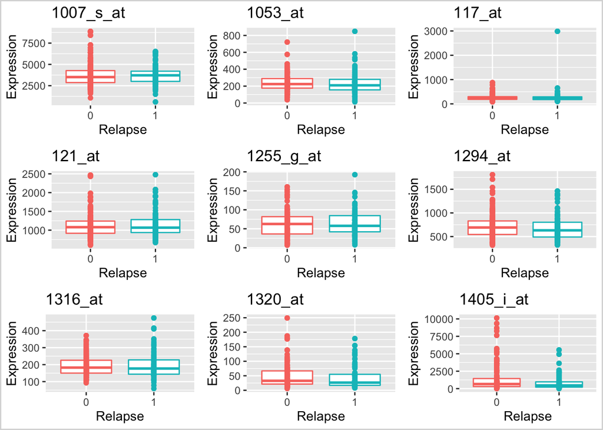

```r
library(cowplot)
Gene1_relapse_no <- ID_gene_patient2 %>%
  ggplot(aes(x=Relapse,y=`1007_s_at`))+geom_boxplot(mapping=aes(color=Relapse),show.legend = FALSE, )+geom_point(mapping=aes(color=Relapse),show.legend = FALSE) + labs(x='Relapse',y='Expression',title = '1007_s_at')
Gene2_relapse_no <- ID_gene_patient2 %>%
  ggplot(aes(x=Relapse,y=`1053_at`))+geom_boxplot(mapping=aes(color=Relapse),show.legend = FALSE, )+geom_point(mapping=aes(color=Relapse),show.legend = FALSE) + labs(x='Relapse',y='Expression',title = '1053_at')
Gene3_relapse_no <- ID_gene_patient2 %>%
  ggplot(aes(x=Relapse,y=`117_at`))+geom_boxplot(mapping=aes(color=Relapse),show.legend = FALSE, )+geom_point(mapping=aes(color=Relapse),show.legend = FALSE) + labs(x='Relapse',y='Expression',title = '117_at')
Gene4_relapse_no <- ID_gene_patient2 %>%
  ggplot(aes(x=Relapse,y=`121_at`))+geom_boxplot(mapping=aes(color=Relapse),show.legend = FALSE, )+geom_point(mapping=aes(color=Relapse),show.legend = FALSE) + labs(x='Relapse',y='Expression',title = '121_at')
Gene5_relapse_no <- ID_gene_patient2 %>%
  ggplot(aes(x=Relapse,y=`1255_g_at`))+geom_boxplot(mapping=aes(color=Relapse),show.legend = FALSE, )+geom_point(mapping=aes(color=Relapse),show.legend = FALSE) + labs(x='Relapse',y='Expression',title = '1255_g_at')
Gene6_relapse_no <- ID_gene_patient2 %>%
  ggplot(aes(x=Relapse,y=`1294_at`))+geom_boxplot(mapping=aes(color=Relapse),show.legend = FALSE, )+geom_point(mapping=aes(color=Relapse),show.legend = FALSE) + labs(x='Relapse',y='Expression',title = '1294_at')
Gene7_relapse_no <- ID_gene_patient2 %>%
  ggplot(aes(x=Relapse,y=`1316_at`))+geom_boxplot(mapping=aes(color=Relapse),show.legend = FALSE, )+geom_point(mapping=aes(color=Relapse),show.legend = FALSE) + labs(x='Relapse',y='Expression',title = '1316_at')
Gene8_relapse_no <- ID_gene_patient2 %>%
  ggplot(aes(x=Relapse,y=`1320_at`))+geom_boxplot(mapping=aes(color=Relapse),show.legend = FALSE, )+geom_point(mapping=aes(color=Relapse),show.legend = FALSE) + labs(x='Relapse',y='Expression',title = '1320_at')
Gene9_relapse_no <- ID_gene_patient2 %>%
  ggplot(aes(x=Relapse,y=`1405_i_at`))+geom_boxplot(mapping=aes(color=Relapse),show.legend = FALSE, )+geom_point(mapping=aes(color=Relapse),show.legend = FALSE) + labs(x='Relapse',y='Expression',title = '1405_i_at')
plot_grid(Gene1_relapse_no,Gene2_relapse_no,Gene3_relapse_no,Gene4_relapse_no,Gene5_relapse_no,Gene6_relapse_no,Gene7_relapse_no,Gene8_relapse_no,Gene9_relapse_no,ncol = 3,labels ="Differential_gene expression_in_patients_with_and_without_relapse") + panel_border()
```

## From the graphs it looks like there is no big difference between the relapse patient group and no relapse group. T-tests are now needed to determine if there are significant differences between the two groups at all:

```r
library(broom)
t1077 <- t.test(ID_gene_patient_relapse$`1007_s_at`,ID_gene_patient_no$`1007_s_at`)
ttable1077 <- tidy(t1077)
t1053 <- t.test(ID_gene_patient_relapse$`1053_at`,ID_gene_patient_no$`1053_at`)
ttable1053 <- tidy(t1053)
t117 <- t.test(ID_gene_patient_relapse$`117_at`,ID_gene_patient_no$`117_at`)
ttable117 <- tidy(t117)
t121 <- t.test(ID_gene_patient_relapse$`121_at`,ID_gene_patient_no$`121_at`)
ttable121 <- tidy(t121)
t1255 <- t.test(ID_gene_patient_relapse$`1255_g_at`,ID_gene_patient_no$`1255_g_at`)
ttable1255 <- tidy(t1255)
t1294 <- t.test(ID_gene_patient_relapse$`1294_at`,ID_gene_patient_no$`1294_at`)
ttable1294 <- tidy(t1294)
t1316 <- t.test(ID_gene_patient_relapse$`1316_at`,ID_gene_patient_no$`1316_at`)
ttable1316 <- tidy(t1316)
t1320 <- t.test(ID_gene_patient_relapse$`1320_at`,ID_gene_patient_no$`1320_at`)
ttable1320 <- tidy(t1320)
t1405 <- t.test(ID_gene_patient_relapse$`1405_i_at`,ID_gene_patient_no$`1405_i_at`)
ttable1405 <- tidy(t1405)
tlist <- list(ttable1077,ttable1053,ttable117,ttable121,ttable1255,ttable1294,ttable1316,ttable1320,ttable1405)
tlist
```

```
## [[1]]
## # A tibble: 1 x 10
##   estimate estimate1 estimate2 statistic p.value parameter conf.low conf.high
##      <dbl>     <dbl>     <dbl>     <dbl>   <dbl>     <dbl>    <dbl>     <dbl>
## 1     60.3     3758.     3698.     0.425   0.671      252.    -219.      339.
## # … with 2 more variables: method <chr>, alternative <chr>
##
## [[2]]
## # A tibble: 1 x 10
##   estimate estimate1 estimate2 statistic p.value parameter conf.low conf.high
##      <dbl>     <dbl>     <dbl>     <dbl>   <dbl>     <dbl>    <dbl>     <dbl>
## 1    -8.99      228.      237.    -0.642   0.522      186.    -36.6      18.6
## # … with 2 more variables: method <chr>, alternative <chr>
##
## [[3]]
## # A tibble: 1 x 10
##   estimate estimate1 estimate2 statistic p.value parameter conf.low conf.high
##      <dbl>     <dbl>     <dbl>     <dbl>   <dbl>     <dbl>    <dbl>     <dbl>
## 1     12.8      268.      256.     0.453   0.652      127.    -43.3      69.0
## # … with 2 more variables: method <chr>, alternative <chr>
##
## [[4]]
## # A tibble: 1 x 10
##   estimate estimate1 estimate2 statistic p.value parameter conf.low conf.high
##      <dbl>     <dbl>     <dbl>     <dbl>   <dbl>     <dbl>    <dbl>     <dbl>
## 1     36.0     1148.     1112.     0.922   0.357      205.    -41.0      113.
## # … with 2 more variables: method <chr>, alternative <chr>
##
## [[5]]
## # A tibble: 1 x 10
##   estimate estimate1 estimate2 statistic p.value parameter conf.low conf.high
##      <dbl>     <dbl>     <dbl>     <dbl>   <dbl>     <dbl>    <dbl>     <dbl>
## 1     1.20      63.1      61.9     0.304   0.761      225.    -6.57      8.97
## # … with 2 more variables: method <chr>, alternative <chr>
##
## [[6]]
## # A tibble: 1 x 10
##   estimate estimate1 estimate2 statistic p.value parameter conf.low conf.high
##      <dbl>     <dbl>     <dbl>     <dbl>   <dbl>     <dbl>    <dbl>     <dbl>
## 1    -57.4      663.      721.     -1.91  0.0573      234.    -117.      1.79
## # … with 2 more variables: method <chr>, alternative <chr>
##
## [[7]]
## # A tibble: 1 x 10
##   estimate estimate1 estimate2 statistic p.value parameter conf.low conf.high
##      <dbl>     <dbl>     <dbl>     <dbl>   <dbl>     <dbl>    <dbl>     <dbl>
## 1     2.52      194.      192.     0.306   0.760      186.    -13.7      18.8
## # … with 2 more variables: method <chr>, alternative <chr>
##
## [[8]]
## # A tibble: 1 x 10
##   estimate estimate1 estimate2 statistic p.value parameter conf.low conf.high
##      <dbl>     <dbl>     <dbl>     <dbl>   <dbl>     <dbl>    <dbl>     <dbl>
## 1    -3.71      43.1      46.8    -0.822   0.412      228.    -12.6      5.18
## # … with 2 more variables: method <chr>, alternative <chr>
##
## [[9]]
## # A tibble: 1 x 10
##   estimate estimate1 estimate2 statistic p.value parameter conf.low conf.high
##      <dbl>     <dbl>     <dbl>     <dbl>   <dbl>     <dbl>    <dbl>     <dbl>
## 1    -494.      812.     1306.     -3.06 0.00242      281.    -811.     -176.
## # … with 2 more variables: method <chr>, alternative <chr>
```

## From the p values it could be seen that among the nine selected genes, only 1405_i_at was differentially expressed in patients with and without relapse.